# Testing of Perceptual Phenomenon

## Question 1: What is our independent variable? What is our dependent variable?

1. The independent variable: The word condition, which can be congruent or incongruent.
2. The dependent variable: The amount of time taken to name ink colors in a list of words with the given word condition.

## Question 2: What is an appropriate set of hypotheses for this task? What kind of statistical test do you expect to perform? Justify your choices.

Definitions:

**Population mean for the congruent case ($\mu_{congruent}$):** This is the population mean for the congruent condition.

**Population mean for the incongruent case ($\mu_{incongruent}$):** This is the population mean for the incongruent condition.

**Null hypothesis ($H_0$):** The null hypothesis states that the population mean for the congruent condition would be equal to the population mean of the incongruent condition.

$$\mu_{congruent} = \mu_{incongruent}$$

**Alternative hypothesis ($H_a$):** The alternative hypothesis states that the population mean for the congruent condition would be different from the population mean of the incongruent condition. This is a two tailed test.

$$\mu_{congruent} \ne \mu_{incongruent}$$

We have a sample distribution as a CSV, but we don’t have the population. We try to infer the population statistics by using the sample statistics. Although we have the sample statistics (mean and std dev), we don’t have the population statistics. Thus, we cannot use the z-test for our hypothesis testing, and will be using t-test.

The pair of samples for a given row is dependent, because it’s the same person taking both the Congruent and the Incongruent test, in some order. The same person is getting tested under two different conditions. Our objective is to look at the difference in the timing between two conditions for the same person. We’re essentially performing a dependent t-test for paired samples.

In our test, we want to conclude whether the sample means in the congruent and the incongruent condition, if different, are really because the underlying population means are also different.

## Question 3: Report some descriptive statistics regarding this dataset. Include at least one measure of central tendency and at least one measure of variability.

```
##    Congruent      Incongruent
##  Min.   : 8.63   Min.   :15.69
##  1st Qu.:11.90   1st Qu.:18.72
##  Median :14.36   Median :21.02
##  Mean   :14.05   Mean   :22.02
##  3rd Qu.:16.20   3rd Qu.:24.05
##  Max.   :22.33   Max.   :35.26
```

## Question 4: Provide one or two visualizations that show the distribution of the sample data. Write one or two sentences noting what you observe about the plot or plots.

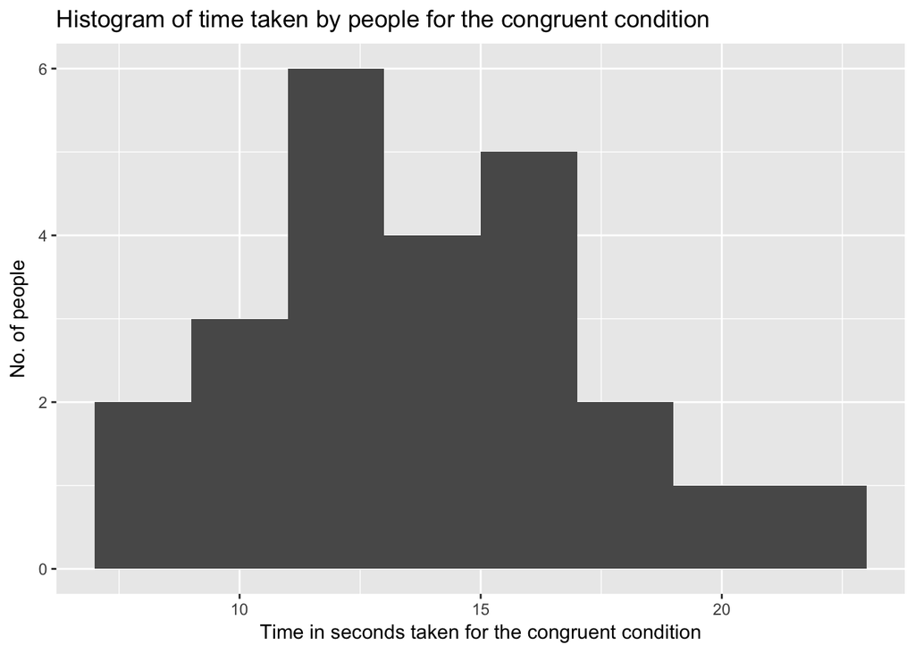

Observations:

1. I adjusted the binwidth to 2 to get the overall pattern of the distribution. At this point, it looks bimodal with a positive skew.

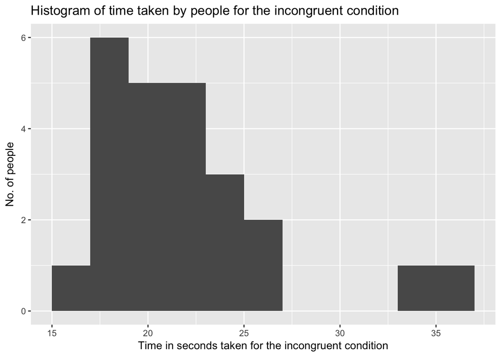

Observations:

1. The histogram for the incongruent condition almost looks like a positively skewed distribution, but for a big gap between 27s to 33s.

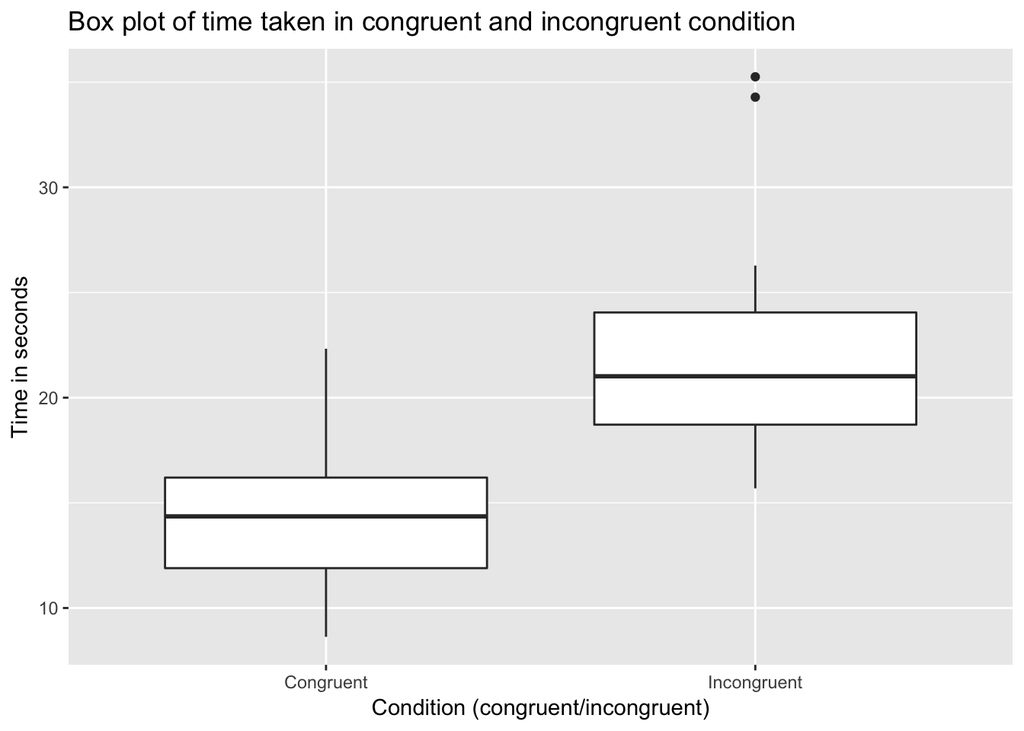

Observations:

1. The incongruent condition has a higher median with two outliers than the congruent condition.
2. At this point, I expect the increase in time in the incongruent condition to be statistically significant, though we’ll verify that using statistical methods.

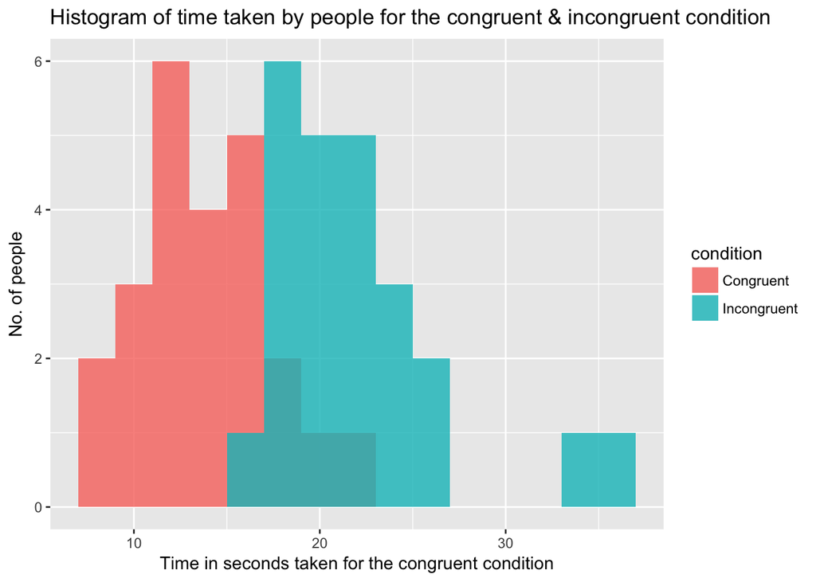

## Now, perform the statistical test and report your results. What is your confidence level and your critical statistic value? Do you reject the null hypothesis or fail to reject it? Come to a conclusion in terms of the experiment task. Did the results match up with your expectations?

### Point estimate

Let’s first look at the point estimate of the differences in timings. This is $\mu_{incongruent} - \mu_{congruent}$.

```
## [1] 7.97
```

Thus, $\mu_{incongruent} - \mu_{congruent} = 7.97$.

### Pair-wise differences in the timing

The next step is to find the SD of the differences in timings. For that, I’ll add a new column to the dataset containing the difference: incongruent - congruent.

```
##    Congruent Incongruent difference
## 1     12.079      19.278      7.199
## 2     16.791      18.741      1.950
## 3      9.564      21.214     11.650
## 4      8.630      15.687      7.057
## 5     14.669      22.803      8.134
## 6     12.238      20.878      8.640
## 7     14.692      24.572      9.880
## 8      8.987      17.394      8.407
## 9      9.401      20.762     11.361
## 10    14.480      26.282     11.802
## 11    22.328      24.524      2.196
## 12    15.298      18.644      3.346
## 13    15.073      17.510      2.437
## 14    16.929      20.330      3.401
## 15    18.200      35.255     17.055
## 16    12.130      22.158     10.028
## 17    18.495      25.139      6.644
## 18    10.639      20.429      9.790
## 19    11.344      17.425      6.081
## 20    12.369      34.288     21.919
## 21    12.944      23.894     10.950
## 22    14.233      17.960      3.727
## 23    19.710      22.058      2.348
## 24    16.004      21.157      5.153
```

### Sample standard deviation of the difference

Next, I’ll find the sample standard deviation of the difference. In case of sample, the denominator represents the degrees of freedom, which is $n - 1$ instead of $n$ as in the case of population SD.

The `R` function `sd` already uses $n - 1$ as the denominator, so that’s what I’ll use.

```
## [1] 4.864827
```

The sample standard deviation of the `difference` variable comes to: 4.864827.

### Calculation of the t-statistic

The t-statistic is given by:

$$t = \frac{\mu_{incongruent} - \mu_{congruent}}{\frac{S}{\sqrt(n)}}$$

```
## [1] 8.025952
```

The value of $t$ comes out to be $8.025952$.

### Critical t values

For a sample size of 24, the degree of freedom is 23. Looking up the critical statistical values from the t-table (https://s3.amazonaws.com/udacity-hosted-downloads/t-table.jpg):

1. $\pm2.069$ for $\alpha = 0.05, \alpha_{tail} = 0.025$
2. $\pm2.807$ for $\alpha = 0.01, \alpha_{tail} = 0.005$
3. $\pm3.786$ for $\alpha = 0.001, \alpha_{tail} = 0.0005$

Since we’re looking at a both the tails, we look up the t-table by first dividing the alpha value by 2.

### Decision on the hypothesis

Thus, we can say that people performed significantly worse in the incongruent condition than in the congruent condition. The results did match my expectations.

## Question 6: What do you think is responsible for the effects observed? Can you think of an alternative or similar task that would result in a similar effect? Some research about the problem will be helpful for thinking about these two questions!

My first hypothesis, even before doing the research, is that the brain tries to do two things. One is to read the text written, and one is to spell out the color of the text. Since the text is the name of a possibly different color, we take time to settle on just one of them. This only happens in the case where the text spells out a name of the color.

On researching online, I discovered multiple theories. One theory was that our brain can process words faster than it can recognize colors. A second theory suggested that the brain requires more attention to recognize a color than read a word. Another theory, which seems to be the most common, is that of automaticity. The brain automatically understands meaning of words due to our practice of reading, and does not require our conscious efforts, whereas color recognition does.

It seems that stroop effect is also observed with warped words, as referenced in Wikipedia (https://en.wikipedia.org/wiki/Stroop_effect). This is interesting, because warped words are normally used to beat computers in captcha. However, it’s a revelation that the task requires more effort from a human.

Another interesting phenomenon is the numerical stroop effect. We generally associate bigger numbers with larger sizes. Comparing digits in incogruent trials (where the smaller digit is written in a larger font) is slower than in the congruent trials (where the larger of the two numbers has a larger font).